# Assignment 2: SQL and R

Khyati Naik

2022-09-11

### Load required packages

```r
library(tidyverse)
library(kableExtra)
library(RMySQL)
library(RODBC)
```

### Connect to MYSQL movies schema

```r
sql_conn <- dbConnect(MySQL(), user= usr, password = pwd, dbname='movies', host='localhost')
```

Please click [here](https://github.com/Naik-Khyati/r_sql/tree/main/input_sql) to access SQL script to create the two tables in database.

### Read the movie rating csv and upload it as a table into movies schema

Read the rating table in r data frame

```r
m_rating_tb = read.csv("https://raw.githubusercontent.com/Naik-Khyati/r_sql/main/input_data/m_rating.csv")
dbWriteTable(sql_conn,"m_rating",m_rating_tb, row.names = FALSE, overwrite = TRUE)
```

```
## [1] TRUE
```

```r
m_rating_dt <- dbGetQuery(sql_conn, 'SELECT * FROM m_rating')
```

### Read the movie name csv and upload it as a table into movies schema

Read the movie name table in r data frame

```r
m_name_tb = read.csv("https://raw.githubusercontent.com/Naik-Khyati/r_sql/main/input_data/m_name.csv")
dbWriteTable(sql_conn,"m_name",m_name_tb, row.names = FALSE, overwrite = TRUE)
```

```
## [1] TRUE
```

```r
m_name_dt <- dbGetQuery(sql_conn, 'SELECT * FROM m_name')
```

### Join movie rating and movie name tables

```r
m_rating_dt <- left_join(m_rating_dt, m_name_dt, by='movie_id')
```

### Replace missing values (NA) with 0

```r
m_rating_dt[is.na(m_rating_dt)] <- 0
```

### Create a rating column from 5 rating category columns

```r
m_rating_dt <- m_rating_dt %>% mutate(rating=pmax(rating1,rating2,rating3,rating4,rating5))
```

### Find the unique values in the data frame for rating

Note that rating=0 represents missing values. As shown in below table, there are 13 movies with missing rating in the dataframe.

```r
m_rating_dt %>% filter (rating==0) %>% group_by(name) %>% summarise(Freq = n())
```

```
## # A tibble: 10 × 2
##    name    Freq
##    <chr>  <int>
##  1 Brian      2
##  2 Cindy      1
##  3 Eul        1
##  4 Greg       1
##  5 Jaya       1
##  6 Matt       1
##  7 Paul       1
##  8 Robert     1
##  9 Sara       1
## 10 Tim        3
```

### Replace missing values

There can be multiple ways to deal with missing values.

- Delete the records with missing values
- Replace missing values with mean/median
- Use some model to predict the values for missing values

**In this data frame, we are going to replace the missing values with average rating for corresponding respondent.**

Below code snippet creates a data frame with average rating by the respondent considering only movies with non missing rating.

```r
missing_values_rep <- m_rating_dt %>% filter (rating!=0) %>% group_by(name) %>% summarise(Freq = n(),avg_rating = min(5,ceiling(mean(rating)))) %>% ungroup()
```

### Join the missing values data frame with movie rating data frame

```r
m_rating_dt <- left_join(m_rating_dt, missing_values_rep, by='name')
```

### Replace the missing rating value with average rating of that respondent

```r
m_rating_dt <- m_rating_dt %>%
    mutate(final_rating = ifelse(rating == 0, avg_rating, rating))
```

### Validate that data frame does not have missing values (i.e. final_rating=0 should not exist)

```r
table(m_rating_dt$final_rating)
```

```
##
##  1  2  3  4  5
## 15 14 13 21 15
```

### Get chart data

Create aggregated data frame for movie name by average rating

```r
chart_data <- m_rating_dt %>% group_by (movie_name) %>% summarise(avg_rating=mean(final_rating))%>%ungroup()
```

### Plot the chart

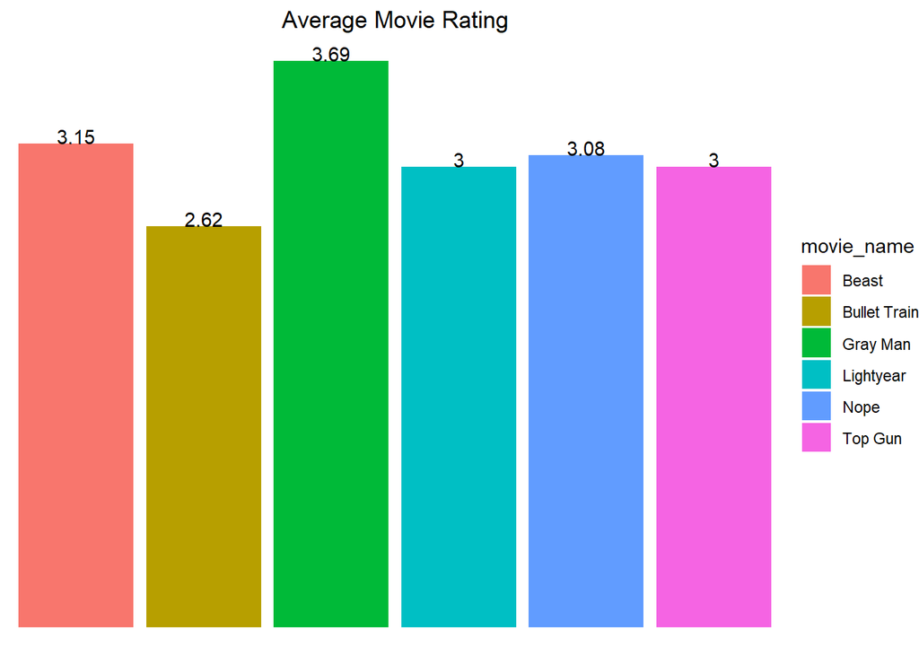

```r
ggplot(chart_data, aes(x = movie_name, y = avg_rating, fill = movie_name)) +
  geom_bar(stat = "identity") +
  geom_text(aes(label = round(avg_rating,digits=2)), vjust = 0) +
  labs(title="Average Movie Rating", x= "Movie", y = "Average Rating") +
  theme_void()+ theme(plot.title=element_text(hjust=0.5))
```

### Conclusion

- In this assignment, we created two tables in movies database. Then, we read those data tables in R data frame. Next we were able to join movie rating and movie name data frames.
- We found that there were 13 records with missing rating in the data frame. Hence, we replaced the missing rating values with average rating values of individual respondents.
- Finally, we plotted a bar chart of movies vs avg rating to find that gray man has the highest average rating and bullet train movie has least average rating.